# اليوم الثاني: تحليل البيانات الجينية وربطها بالبيانات الإكلينيكية

# ماهي ملفات MAF؟

ملف **MAF** هو اختصار لـ **Mutation Annotation Format**، وهو صيغة ملفات قياسية تُستخدم بشكل واسع في المعلوماتية الحيوية (Bioinformatics) لتخزين وتمثيل بيانات الطفرات الجينية المكتشفة في الدراسات الجينومية، خصوصًا في مجال أبحاث السرطان.

يُعتبر ملف الـ MAF تنسيقًا جدوليًا (جدول نصي مفصول بفواصل أو تبويبات) يضم معلومات وصفية عن كل طفرة جينية، بحيث يتيح للباحثين تبادل البيانات وتحليلها بطريقة موحّدة ومنظمة.

**🟠 المحتويات الأساسية لملف MAF:**

▪️ **Gene Symbol (رمز الجين)**: اسم الجين الذي حدثت فيه الطفرة.

▪️ **Chromosome (الكروموسوم)**: موقع الطفرة على الكروموسوم.

▪️ **Start/End Position (موضع البداية والنهاية):** الموقع الجينومي للطفرات.

▪️ **Variant Classification (تصنيف الطفرة):** يحدد نوع الطفرة (مثل: Silent، Missense، Nonsense، Frame-shift…).

▪️ **Variant Type (نوع التغير):** مثل SNP (تعدد أشكال النوكليوتيدات المفردة) أو Insertion أو Deletion.

▪️ **Reference & Tumor Allele (الأليل المرجعي وأليل الورم):** مقارنة بين التسلسل المرجعي والتغير المرصود.

▪️ **Sample Information (معلومات العينة):** مثل المريض، نوع النسيج (ورمي أو طبيعي).

ننطلق الآن للعمل على هذا الملف!

## 1. سنقوم بتهيئة بيئة العمل، ثم نحمّل الحزم البرمجية التي سنحتاج إليها أثناء هذه الورشة.

```r
library(maftools)
library(dplyr)
library(skimr)
library(tidyverse)
```

```r
library(ggplot2)
library(data.table)
library(ggrepel)
```

## 2. نقوم بقراءة ملف البيانات الوصفية الذي تم حفظه في اليوم الأول

```r
url <- "https://raw.githubusercontent.com/Dalah-Info/health-info-bioinformatics-r/refs/heads/main/Day1/Breast_tumor_metadata_cleaned.csv"
Breast_tumor_metadata = read.csv(url,  row.names = NULL)
```

## 3. نقوم بقراءة ملف الطفرات الجينية: MFA

```r
url2 <- "https://github.com/Dalah-Info/health-info-bioinformatics-r/raw/refs/heads/main/maf_file/filtered_maf_breast_only_maftools.maf.gz"
maf_file = read.maf(maf = url2)
```

```
## -Reading
## -Validating
## -Silent variants: 44872
## -Summarizing
## --Possible FLAGS among top ten genes:
##   TTN
##   MUC16
##   FLG
## -Processing clinical data
## --Missing clinical data
## -Finished in 20.1s elapsed (15.1s cpu)
```

## 4. نستكشف شكل ملف MAF والبيانات المسجلة فيه

```r
head(maf_file@data) #البيانات الوصفية للحينات نجدها في هذه الخانة
```

| Hugo_Symbol | Entrez_Gene_Id | Center | NCBI_Build | Chromosome | Start_Position | End_Position | Strand | Variant_Classification | Variant_Type | Reference_Allele | Tumor_Seq_Allele1 | Tumor_Seq_Allele2 | dbSNP_RS | dbSNP_Val_Status | Tumor_Sample_Barcode | Matched_Norm_Sample_Barcode | Match_Norm_Seq_Allele1 | Match_Norm_Seq_Allele2 | Tumor_Validation_Allele1 | Tumor_Validation_Allele2 | Match_Norm_Validation_Allele1 | Match_Norm_Validation_Allele2 | Verification_Status | Validation_Status | Mutation_Status | Sequencing_Phase | Sequence_Source | Validation_Method | Score | … |
| --- | --- | --- | --- | --- | --- | --- | --- | --- | --- | --- | --- | --- | --- | --- | --- | --- | --- | --- | --- | --- | --- | --- | --- | --- | --- | --- | --- | --- | --- | --- |
| GATA3 | 0 | . | GRCh37 | 10 | 8115874 | 8115875 | + | Frame_Shift_Ins | INS | - | - | A | . | . | TCGA-3C-AAAU-01A-11D-A41F-09 | TCGA-3C-AAAU-10A-01D-A41F-09 | - | - | . | . | . | . | . | . | . | . | . | . | . | … |
| CD248 | 0 | . | GRCh37 | 11 | 66082467 | 66082467 | + | Missense_Mutation | SNP | C | C | T | rs373617917 | . | TCGA-3C-AAAU-01A-11D-A41F-09 | TCGA-3C-AAAU-10A-01D-A41F-09 | C | C | . | . | . | . | . | . | . | . | . | . | . | … |
| MIPOL1 | 0 | . | GRCh37 | 14 | 37838785 | 37838785 | + | Missense_Mutation | SNP | A | A | G | rs756594798 | . | TCGA-3C-AAAU-01A-11D-A41F-09 | TCGA-3C-AAAU-10A-01D-A41F-09 | A | A | . | . | . | . | . | . | . | . | . | . | . | … |
| THSD4 | 0 | . | GRCh37 | 15 | 72039337 | 72039337 | + | Missense_Mutation | SNP | C | C | G | novel | . | TCGA-3C-AAAU-01A-11D-A41F-09 | TCGA-3C-AAAU-10A-01D-A41F-09 | C | C | . | . | . | . | . | . | . | . | . | . | . | … |
| TGFB1 | 0 | . | GRCh37 | 19 | 41837051 | 41837051 | + | Missense_Mutation | SNP | G | G | A | novel | . | TCGA-3C-AAAU-01A-11D-A41F-09 | TCGA-3C-AAAU-10A-01D-A41F-09 | G | G | . | . | . | . | . | . | . | . | . | . | . | … |
| CADM4 | 0 | . | GRCh37 | 19 | 44129230 | 44129230 | + | Missense_Mutation | SNP | C | C | A | rs756727777 | . | TCGA-3C-AAAU-01A-11D-A41F-09 | TCGA-3C-AAAU-10A-01D-A41F-09 | C | C | . | . | . | . | . | . | . | . | . | . | . | … |

نقوم باستخدام أداة **skimr** لتقرأ لنا الملف الوصفي كاملا

```r
skim(maf_file@data)
```

Data summary

| Name | maf_file@data |
| --- | --- |
| Number of rows | 85864 |
| Number of columns | 114 |
| Key | NULL |
| _______________________ |  |
| Column type frequency: |  |
| character | 100 |
| factor | 3 |
| numeric | 11 |
| ________________________ |  |
| Group variables | None |

**Variable type: character**

| skim_variable | n_missing | complete_rate | min | max | empty | n_unique | whitespace |
| --- | --- | --- | --- | --- | --- | --- | --- |
| Hugo_Symbol | 0 | 1 | 1 | 18 | 0 | 16686 | 0 |
| Center | 0 | 1 | 1 | 1 | 0 | 1 | 0 |
| NCBI_Build | 0 | 1 | 6 | 6 | 0 | 1 | 0 |
| Chromosome | 0 | 1 | 1 | 2 | 0 | 24 | 0 |
| Strand | 0 | 1 | 1 | 1 | 0 | 1 | 0 |
| Reference_Allele | 0 | 1 | 1 | 61745 | 0 | 1184 | 0 |
| Tumor_Seq_Allele1 | 0 | 1 | 1 | 61745 | 0 | 1184 | 0 |
| Tumor_Seq_Allele2 | 0 | 1 | 1 | 66 | 0 | 186 | 0 |
| dbSNP_RS | 0 | 1 | 1 | 35 | 0 | 21513 | 0 |
| dbSNP_Val_Status | 0 | 1 | 1 | 1 | 0 | 1 | 0 |
| Matched_Norm_Sample_Barcode | 0 | 1 | 28 | 28 | 0 | 1040 | 0 |
| Match_Norm_Seq_Allele1 | 0 | 1 | 1 | 61745 | 0 | 1184 | 0 |
| Match_Norm_Seq_Allele2 | 0 | 1 | 1 | 61745 | 0 | 1184 | 0 |
| Tumor_Validation_Allele1 | 0 | 1 | 1 | 1 | 0 | 1 | 0 |
| Tumor_Validation_Allele2 | 0 | 1 | 1 | 1 | 0 | 1 | 0 |
| Match_Norm_Validation_Allele1 | 0 | 1 | 1 | 1 | 0 | 1 | 0 |
| Match_Norm_Validation_Allele2 | 0 | 1 | 1 | 1 | 0 | 1 | 0 |
| Verification_Status | 0 | 1 | 1 | 1 | 0 | 1 | 0 |
| Validation_Status | 0 | 1 | 1 | 1 | 0 | 1 | 0 |
| Mutation_Status | 0 | 1 | 1 | 1 | 0 | 1 | 0 |
| Sequencing_Phase | 0 | 1 | 1 | 1 | 0 | 1 | 0 |
| Sequence_Source | 0 | 1 | 1 | 1 | 0 | 1 | 0 |
| Validation_Method | 0 | 1 | 1 | 1 | 0 | 1 | 0 |
| Score | 0 | 1 | 1 | 1 | 0 | 1 | 0 |
| BAM_File | 0 | 1 | 1 | 1 | 0 | 1 | 0 |
| Sequencer | 0 | 1 | 1 | 1 | 0 | 1 | 0 |
| Tumor_Sample_UUID | 0 | 1 | 1 | 1 | 0 | 1 | 0 |
| Matched_Norm_Sample_UUID | 0 | 1 | 1 | 1 | 0 | 1 | 0 |
| HGVSc | 0 | 1 | 1 | 22890 | 0 | 39030 | 0 |
| HGVSp | 0 | 1 | 1 | 90 | 0 | 59584 | 0 |

[output cut: 70 more lines]

**Variable type: factor**

| skim_variable | n_missing | complete_rate | ordered | n_unique | top_counts |
| --- | --- | --- | --- | --- | --- |
| Variant_Classification | 0 | 1 | FALSE | 9 | Mis: 67056, Fra: 9253, Non: 5699, Spl: 2022 |
| Variant_Type | 0 | 1 | FALSE | 4 | SNP: 74579, DEL: 10251, INS: 1032, ONP: 2 |
| Tumor_Sample_Barcode | 0 | 1 | FALSE | 1026 | TCG: 5366, TCG: 4161, TCG: 3899, TCG: 3078 |

**Variable type: numeric**

| skim_variable | n_missing | complete_rate | mean | sd | p0 | p25 | p50 | p75 | p100 | hist |
| --- | --- | --- | --- | --- | --- | --- | --- | --- | --- | --- |
| Entrez_Gene_Id | 0 | 1 | 0.00 | 0.00 | 0 | 0 | 0 | 0 | 0 | ▁▁▇▁▁ |
| Start_Position | 0 | 1 | 80053074.65 | 58360981.52 | 59392 | 34148848 | 65352191 | 119609094 | 249212537 | ▇▆▃▂▁ |
| End_Position | 0 | 1 | 80053080.87 | 58360977.01 | 59392 | 34148848 | 65352191 | 119609094 | 249212537 | ▇▆▃▂▁ |
| t_depth | 0 | 1 | 130.00 | 134.09 | 7 | 50 | 91 | 165 | 3230 | ▇▁▁▁▁ |
| t_ref_count | 0 | 1 | 103.56 | 115.29 | 0 | 37 | 69 | 132 | 3150 | ▇▁▁▁▁ |
| t_alt_count | 0 | 1 | 26.15 | 34.67 | 2 | 9 | 16 | 30 | 3063 | ▇▁▁▁▁ |
| n_depth | 0 | 1 | 114.58 | 114.02 | 8 | 45 | 79 | 143 | 4046 | ▇▁▁▁▁ |
| n_ref_count | 0 | 1 | 114.53 | 113.98 | 7 | 45 | 79 | 143 | 4045 | ▇▁▁▁▁ |
| n_alt_count | 0 | 1 | 0.03 | 0.18 | 0 | 0 | 0 | 0 | 9 | ▇▁▁▁▁ |
| STRAND | 0 | 1 | -0.01 | 1.00 | -1 | -1 | -1 | 1 | 1 | ▇▁▁▁▇ |
| NCALLERS | 0 | 1 | 3.88 | 1.23 | 2 | 3 | 4 | 5 | 7 | ▆▃▇▁▁ |

## 5. دمج ملف البيانات الوصفية والاكلينيكية مع ملف MAF

**لماذا؟ 🔴**

عادة ما يأتي ملف MAF منفصلا عن الملف الوصفي، ونحتاج لدمجهما معًا حتى نتمكن من تحليل الطفرات وربطها بهذه البيانات.

**كيف؟ 🔴**

نحتاج إلى عمود واحد مشترك بين الملفين، عادة يكون رمز العينة

**أين نجد رمز العينة؟ 🔴**

في ملف MAF، هناك نمطان من ترميز العينات (Sample Barcoding) يجب الانتباه لهما:

1. نمط TCGA
2. نمط UUID

اختر النمط الموجود في ملف الـ MAF وأيضًا في البيانات الوصفية (Metadata)، حتى تتمكن من ربط الجدولين باستخدام هذا العمود.

```r
head(unique(maf_file@data$Tumor_Sample_UUID), 5) #لايوجد مدخلات
```

```
## [1] "."
```

```r
head(unique(maf_file@data$Tumor_Sample_Barcode),5)
```

```
## [1] TCGA-3C-AAAU-01A-11D-A41F-09 TCGA-3C-AALI-01A-11D-A41F-09
## [3] TCGA-3C-AALJ-01A-31D-A41F-09 TCGA-3C-AALK-01A-11D-A41F-09
## [5] TCGA-4H-AAAK-01A-12D-A41F-09
## 1026 Levels: TCGA-3C-AAAU-01A-11D-A41F-09 ... TCGA-Z7-A8R6-01A-11D-A41F-09
```

سوف نختار رمز TCGA لأن UUID غير موجود في ملف الـ MAF.

**🔴 رمز العينة في ملف MAF:**

*TCGA-OL-A66K-01A-11D-A29N-09* هو رمز كامل للعينة (sample/aliquot barcode). ويتكوّن من:

▪️ TCGA → المشروع (Project)

▪️ OL → موقع مصدر النسيج (Tissue Source Site - TSS)

▪️ A66K → معرّف المشارك (المريض) (Participant/Patient ID)

▪️ 01A → نوع العينة + القارورة (01 = ورم أولي “Primary tumor” ؛ A = قارورة)

▪️ 11D → الجزء + المحلل الحيوي (11 = جزء، D = DNA)

▪️ A29N → الصفيحة (Plate)

▪️ 09 → المركز (Center)

هل توجد هذه البيانات في ملف البيانات الوصفية؟ لنتحقق من ذلك

```r
head(unique(Breast_tumor_metadata$bcr_patient_barcode),5)
```

```
## [1] "TCGA-3C-AAAU" "TCGA-3C-AALI" "TCGA-3C-AALJ" "TCGA-3C-AALK" "TCGA-4H-AAAK"
```

**🔴رمز العينة في البيانات الوصفية (Metadata):**

لدينا فقط رمز المريض (Patient Barcode) مثل: *TCGA-EW-A6S9*، وهو يتكون فقط من أول 12 حرفًا من رمز الـ TCGA الكامل الموجود في ملف MAF.

✅ إذن القاعدة هي: **رمز المريض في الملف الوصفي = أول 12 حرف من رمز العينة في ملف MAF**.

```r
#ننشئ ملف بيانات يحتوي على الرمز الطويل والقصير للمريض، لنستخدمه لاحقا للدمج.

id_map <- data.frame(
  short_id = substr(maf_file@data$Tumor_Sample_Barcode, 1, 12),             # معرّف المريض (12 حرف)
  Tumor_Sample_Barcode = as.character(maf_file@data$Tumor_Sample_Barcode),  # المعرّف الكامل للعينة
  stringsAsFactors = FALSE
)

#إزالة التكرار على مستوى المريض
id_map <- id_map[!duplicated(id_map$short_id), ]


matched_clinical_data <- merge(
  x = Breast_tumor_metadata,     # البيانات السريرية
  y = id_map,                    # خريطة المعرّفات من ملف الـ MAF
  by.x = "bcr_patient_barcode",  # اسم عمود المريض في البيانات السريرية
  by.y = "short_id",             # اسم عمود المريض (12 حرف) في الخريطة
  all.x = FALSE                  # احتفظ فقط بالمرضى الموجودين في الـ MAF
)


## الآن: matched_clinical_data يحوي فقط المرضى المطابقين، وبداخله عمود Tumor_Sample_Barcode المشترك.
```

**✅ نستطيع الآن إنشاء ملف MAF مكتمل، يحتوي على البيانات الوصفية الإكلينيكية:**

```r
maf_file <- read.maf(maf = url2, clinicalData = matched_clinical_data, verbose = F)
```

## 5. ننطلق الآن لاستكشاف الطفرات الجينية المُسجلة في ملف MAF!

### 5.1 ملخص الطفرات المٌسجلة في ملف MAF لكل مريض.🩺

```r
getSampleSummary(maf_file)
```

| Tumor_Sample_Barcode | Frame_Shift_Del | Frame_Shift_Ins | In_Frame_Del | In_Frame_Ins | Missense_Mutation | Nonsense_Mutation | Nonstop_Mutation | Splice_Site | Translation_Start_Site | total |
| --- | --- | --- | --- | --- | --- | --- | --- | --- | --- | --- |
| TCGA-AN-A046-01A-21W-A050-09 | 3 | 12 | 0 | 0 | 4497 | 757 | 6 | 91 | 0 | 5366 |
| TCGA-AC-A23H-01A-11D-A159-09 | 16 | 3 | 1 | 0 | 3647 | 404 | 7 | 73 | 10 | 4161 |
| TCGA-EW-A2FV-01A-11D-A17D-09 | 3846 | 0 | 0 | 0 | 19 | 0 | 0 | 34 | 0 | 3899 |
| TCGA-D8-A27V-01A-12D-A17D-09 | 2875 | 0 | 1 | 0 | 140 | 16 | 0 | 45 | 1 | 3078 |
| TCGA-BH-A18G-01A-11D-A12B-09 | 128 | 40 | 12 | 0 | 974 | 46 | 1 | 33 | 2 | 1236 |
| TCGA-AN-A0AK-01A-21W-A019-09 | 131 | 48 | 33 | 2 | 812 | 47 | 0 | 33 | 1 | 1107 |
| TCGA-A8-A09Z-01A-11W-A019-09 | 109 | 45 | 22 | 1 | 828 | 40 | 3 | 34 | 2 | 1084 |
| TCGA-5L-AAT1-01A-12D-A41F-09 | 0 | 3 | 0 | 0 | 884 | 125 | 3 | 17 | 3 | 1035 |
| TCGA-D8-A1XK-01A-21D-A14K-09 | 68 | 15 | 2 | 0 | 781 | 17 | 1 | 61 | 0 | 945 |
| TCGA-BH-A0HF-01A-11W-A071-09 | 1 | 1 | 0 | 0 | 750 | 51 | 0 | 27 | 0 | 830 |

[output cut: 1016 more lines]

### 5.2 ملخص الطفرات المٌسجلة في ملف MAF لكل جين.🧬

```r
getGeneSummary(maf_file)
```

| Hugo_Symbol | Frame_Shift_Del | Frame_Shift_Ins | In_Frame_Del | In_Frame_Ins | Missense_Mutation | Nonsense_Mutation | Nonstop_Mutation | Splice_Site | Translation_Start_Site | total | MutatedSamples | AlteredSamples |
| --- | --- | --- | --- | --- | --- | --- | --- | --- | --- | --- | --- | --- |
| PIK3CA | 0 | 0 | 15 | 0 | 378 | 0 | 0 | 0 | 0 | 393 | 352 | 352 |
| TP53 | 48 | 14 | 5 | 0 | 217 | 47 | 0 | 25 | 0 | 356 | 350 | 350 |
| TTN | 22 | 0 | 1 | 1 | 271 | 20 | 0 | 6 | 0 | 321 | 193 | 193 |
| CDH1 | 35 | 33 | 4 | 0 | 16 | 31 | 0 | 13 | 0 | 132 | 130 | 130 |
| GATA3 | 24 | 65 | 1 | 0 | 14 | 4 | 0 | 23 | 0 | 131 | 128 | 128 |
| MUC16 | 15 | 1 | 0 | 0 | 132 | 8 | 0 | 0 | 0 | 156 | 112 | 112 |
| KMT2C | 22 | 10 | 1 | 0 | 45 | 35 | 0 | 3 | 0 | 116 | 98 | 98 |
| MAP3K1 | 39 | 32 | 4 | 0 | 29 | 23 | 0 | 4 | 0 | 131 | 90 | 90 |
| FLG | 1 | 0 | 2 | 0 | 71 | 4 | 0 | 0 | 0 | 78 | 68 | 68 |
| RYR2 | 2 | 0 | 0 | 0 | 75 | 3 | 0 | 4 | 0 | 84 | 66 | 66 |

[output cut: 9990 more lines]

### 5.3 رسم ملخص شامل لمعظم البيانات

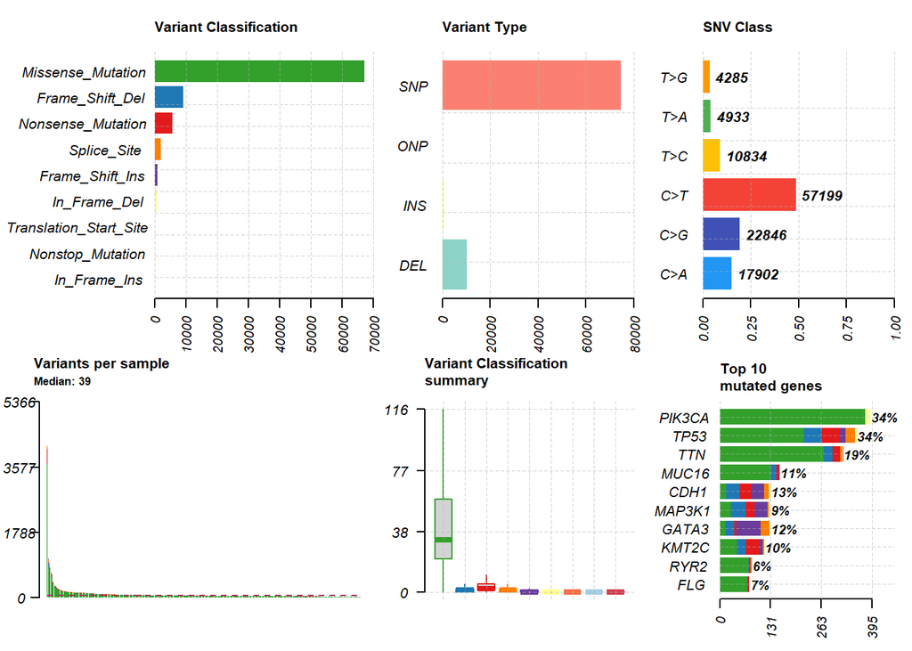

```r
# رسم ملخص شامل: عدد الطفرات، نسب الأنواع المختلفة، إحصائيات عامة

plotmafSummary(maf = maf_file, rmOutlier = TRUE, addStat = 'median', dashboard = TRUE, titvRaw = FALSE)
```

### 5.4 رسم Oncoplot لأكثر 10 جينات تعرضاً للطفرات

تعبر رسمة الـ **oncoplot** واحدة من أشهر الرسومات المرتبطة بدراسة الطفرات ساعد الباحث على رؤية الأنماط الجينية (mutation patterns) وتحديد الجينات الحرجة في تطور السرطان.

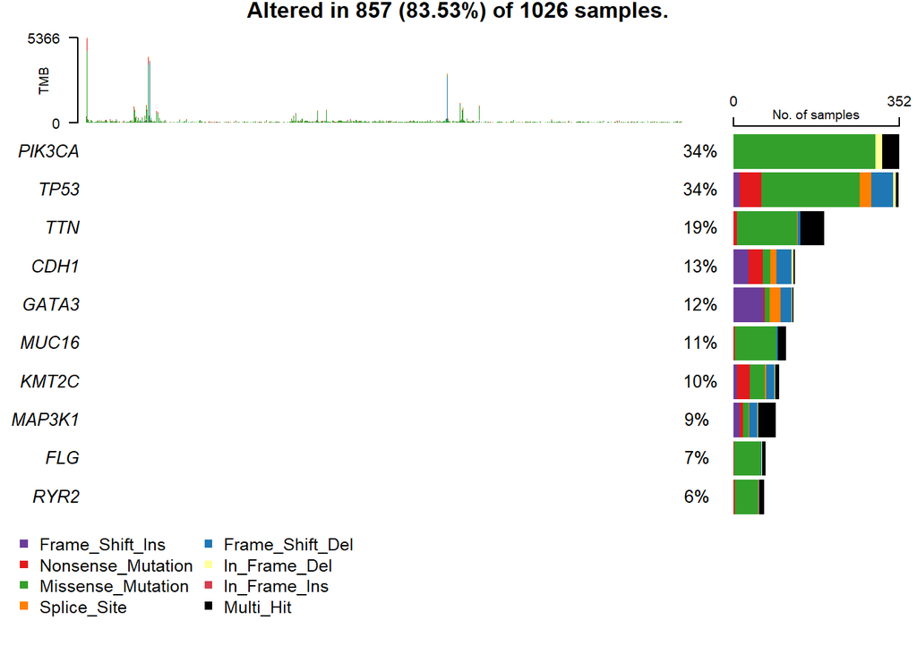

```r
# oncoplot يعرض الجينات الأعلى تكراراً في عينات المرضى

oncoplot(maf = maf_file, top = 10)
```

### 5.5 🔄 تحليل Transition / Transversion (Ti/Tv)

**🔹 Transition (Ti):** هي استبدال بيريميدين ↔︎ بيريميدين (C↔︎T) أو بيورين ↔︎ بيورين (A↔︎G).

→ نوع “محافظ” أكثر (conservative)، ويحدث بشكل شائع.

**🔹 Transversion (Tv):** هي استبدال بيريميدين ↔︎ بيورين (C↔︎A, C↔︎G, T↔︎A, T↔︎G).

→ أقل شيوعًا، لكنها قد تكون مؤثرة أكثر على البروتين.

⚖️ النسبة Ti/Tv تُستخدم كمقياس في دراسات الطفرات، وغالبًا تكون ≈ 2–3 في معظم الأورام والـ exomes (لأن Ti تحدث أكثر).

**🔹 الفائدة من تحليل Ti/Tv:**

تقييم جودة بيانات التسلسل (NGS): نسبة Ti/Tv المنطقية تدل أن البيانات سليمة وغير ملوثة بأخطاء تسلسل.

تحديد البصمات الطفرية (Mutational Signatures): بعض السرطانات أو عوامل البيئة (تدخين، أشعة UV، إلخ) تُظهر أنماط Ti/Tv مختلفة.

فهم الآليات البيولوجية للطفرات: مثلًا:

▪️ UV → يسبب C>T transitions.

▪️ التدخين → يزيد C>A transversions.

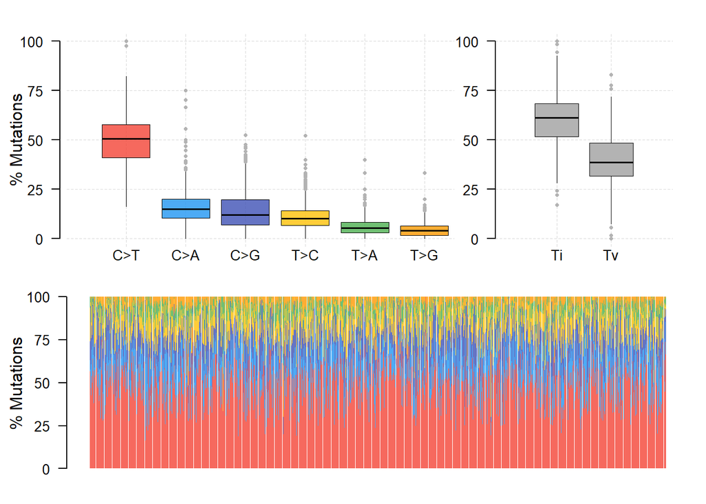

```r
# حساب أنواع الاستبدال (Ti/Tv) في الطفرات

 laml.titv = titv(maf = maf_file, plot = FALSE, useSyn = TRUE)

 # رسم ملخص Ti/Tv
plotTiTv(res = laml.titv)
```

✅ الخلاصة: التحليل يوضح أن الـ C>T transition هو الأكثر شيوعًا، وأن النسبة الإجمالية للطفرات تميل لصالح الـ Transitions (Ti) مقارنةً بالـ Transversions (Tv)، وهو نمط متوقع ويدعم أن البيانات ذات جودة عالية.

### 5.6 رسم توزيع الأليلات: Variant Allele Frequency (VAF)

**🔹 ما هو الـ VAF؟**

VAF = نسبة القراءات (Reads) التي تحمل الطفرة ÷ إجمالي القراءات المغطية لهذا الموضع. مثال: لو عندنا 100 قراءة على موقع جيني، و40 منها فيها طفرة → VAF = 0.4 (40%).

يُستخدم كمقياس لاحتمالية أن تكون الطفرة:

طفرة جسدية (somatic mutation).

طفرة من السلالة التناسلية (germline mutation).

أو ناتجة عن heterogeneity (اختلاط خلايا مختلفة داخل الورم).

**🔹 ماذا نستنتج من هذا النوع من التحليل؟**

الطفرات ذات VAF مرتفع (~0.5 أو أعلى):

قد تكون طفرة مؤسِّسة (founder mutation) في الورم.

أو أحيانًا طفرة germline (موروثة).

الطفرات ذات VAF منخفض (<0.3 تقريبًا):

غالبًا subclonal mutations → موجودة في نسبة من الخلايا الورمية فقط.

تعكس تغايرية الورم (tumor heterogeneity).

توزيع VAF يختلف بين الجينات:

مثلًا: TP53 غالبًا يظهر بطفرات عالية التكرار وVAF متوسط–عالٍ، مما يدل على أنه جين أساسي في نشأة الورم (driver gene).

بينما جينات مثل TTN, MUC16 غالبًا تُظهر VAF أكثر تنوعًا لأنها جينات كبيرة الحجم وتراكم فيها الطفرات (passenger mutations).

```
## t_vaf field is missing, but found t_ref_count & t_alt_count columns. Estimating vaf..
```

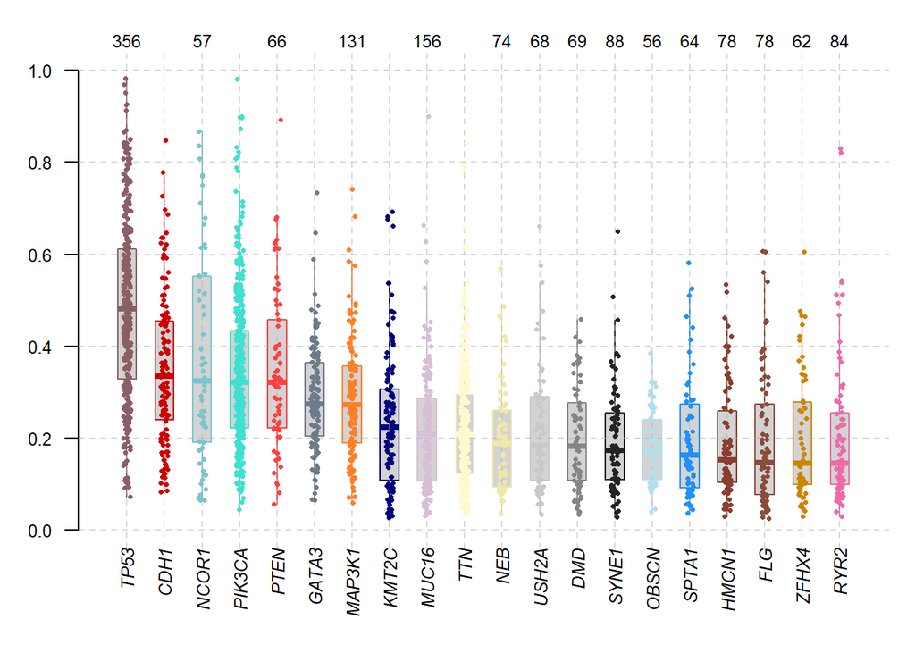

```r
plotVaf(maf = maf_file, vafCol = NULL, top = 20)
```

### 5.7 ⚔️ تحليل العلاقة بين الجينات، هل تحدث الطفرتين معا؟

نحاول فهم علاقة الطفرات ببعضها، هل هي طفرات تعاونية (تظهر عادة معا)، أم بديلة (واحد منها يكفي لخلق الأثر.)

وهذا يساعد على فهم المسارات الجزيئية في السرطان وربما اقتراح أهداف علاجية (إذا كان مسار محدد هو المسيطر).

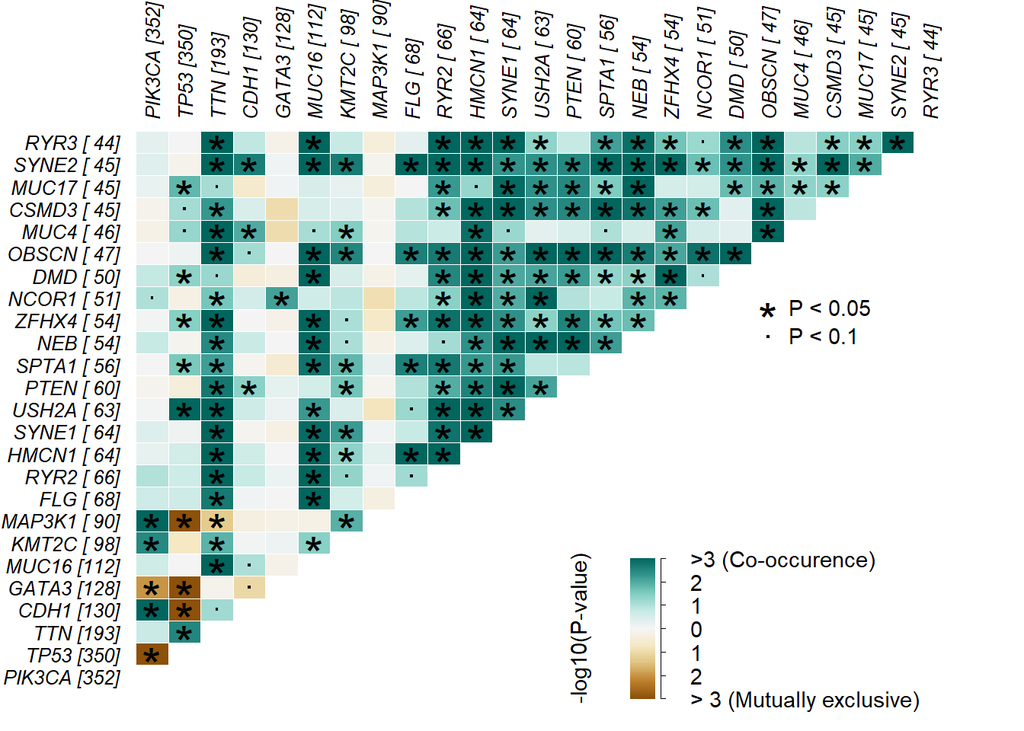

| gene1 | gene2 | pValue | oddsRatio | 00 | 01 | 11 | 10 | pAdj | Event | pair | event_ratio |
| --- | --- | --- | --- | --- | --- | --- | --- | --- | --- | --- | --- |
| TP53 | CDH1 | 1.487319e-14 | 0.1212479 | 555 | 121 | 9 | 341 | 3.442869e-13 | Mutually_Exclusive | CDH1, TP53 | 9/462 |
| GATA3 | TP53 | 1.511579e-12 | 0.1552365 | 559 | 339 | 11 | 117 | 3.257713e-11 | Mutually_Exclusive | GATA3, TP53 | 11/456 |
| HMCN1 | TTN | 2.268967e-08 | 4.6293475 | 800 | 162 | 31 | 33 | 4.574530e-07 | Co_Occurence | HMCN1, TTN | 31/195 |
| MUC16 | TTN | 6.316428e-08 | 3.3171099 | 765 | 149 | 44 | 68 | 1.196293e-06 | Co_Occurence | MUC16, TTN | 44/217 |
| PIK3CA | TP53 | 8.709609e-08 | 0.4604239 | 406 | 268 | 82 | 270 | 1.555287e-06 | Mutually_Exclusive | PIK3CA, TP53 | 82/538 |
| OBSCN | HMCN1 | 2.249928e-07 | 7.8492944 | 929 | 50 | 14 | 33 | 3.800554e-06 | Co_Occurence | HMCN1, OBSCN | 14/83 |
| MAP3K1 | TP53 | 3.132293e-07 | 0.2193640 | 596 | 340 | 10 | 80 | 4.859735e-06 | Mutually_Exclusive | MAP3K1, TP53 | 10/420 |
| TTN | RYR3 | 3.187986e-07 | 5.2194206 | 812 | 21 | 23 | 170 | 4.859735e-06 | Co_Occurence | RYR3, TTN | 23/191 |
| HMCN1 | RYR2 | 6.331743e-07 | 6.0597649 | 912 | 50 | 16 | 48 | 9.203115e-06 | Co_Occurence | HMCN1, RYR2 | 16/98 |
| ZFHX4 | MUC16 | 8.801728e-07 | 5.1172628 | 879 | 93 | 19 | 35 | 1.222462e-05 | Co_Occurence | MUC16, ZFHX4 | 19/128 |

[output cut: 290 more lines]

```r
# يكشف عن علاقة التعايش أو التنافي بين الطفرات في الجينات

somaticInteractions(maf = maf_file, top = 25, pvalue = c(0.05, 0.1))
```

**🔹 ماذا نستنتج من الشكل؟**

TP53 ↔︎ PIK3CA: العلاقة بنية (mutually exclusive) → عادةً لا يتحوران معًا، قد يشير أن كل منهما يكفي لدفع الورم.

معظم الجينات الأخرى (MUC16, TTN, SYNE1, FLG… إلخ): تظهر ارتباطات موجبة قوية جدًا (* أخضر داكن)، مما قد يعكس كونها “Passenger mutations” متجمعة.

تفسير بيولوجي:

Co-occurrence: يوحي بأن الجينات تعمل في مسارات مختلفة لكن تكاملية، والورم يستفيد من تحويرهما معًا.

Mutual exclusivity: يوحي بأن الجينات تعمل في نفس المسار (pathway redundancy)، وطفرات أحدهما تكفي لتعطيل المسار.

## 6. تحليل تأثير الطفرات على الحياة (هل تؤثر الطفرات في هذا الجين على مدة العيش؟)

لإجراء هذا التحليل نحتاج معلومتين رئيسيتين: 1) حالة المريض: حي أو متوفى. ويجب كتابتها بطريقة 0 أو 1، حيث أن 0 ترمز للحياة و 1 ترمز للوفاة. 2) يجب أن يكون لدينا عدد الأيام حتى آخر زيارة للمريض أو حتى وقت الوفاة.

### 6.1 نتأكد بأن البيانات تستوفي الشكل المطلوب لتطبيق التحليل

```r
# 1) تحويل حالة الوفاة إلى 0/1
maf_file@clinical.data$vital_status <- ifelse(maf_file@clinical.data$vital_status %in% c("Dead", "1"), 1, 0)

# 2) تحويل الأيام إلى قيم رقمية
num <- function(x) suppressWarnings(as.numeric(as.character(x)))
dtd  <- num(maf_file@clinical.data$days_to_death)
dtlf <- num(maf_file@clinical.data$days_to_last_followup)

# 3) حساب زمن البقاء (OS.time): وقت الوفاة أو آخر متابعة

maf_file@clinical.data$OS.time <- ifelse(!is.na(dtd), dtd, dtlf)

# تأكيد أن القيم رقمية

maf_file@clinical.data[,vital_status :=  as.numeric(vital_status)]
maf_file@clinical.data[,OS.time :=  as.numeric(OS.time)]
```

### 6.2 🧬نقوم بتحليل تأثير الطفرات على الحياة في جين واحد فقط

```r
# 4) تحليل البقاء لجين محدد (مثال: NEB)

mafSurvival(maf = maf_file, genes = 'NEB', time = 'OS.time', Status = 'vital_status', isTCGA = FALSE)
```

```
## Looking for clinical data in annoatation slot of MAF..
```

```
## Number of mutated samples for given genes:
```

```
## NEB
##  54
```

```
## Median survival..
```

```
##     Group medianTime     N
##    <char>      <num> <int>
## 1: Mutant      984.5    54
## 2:     WT      823.5   966
```

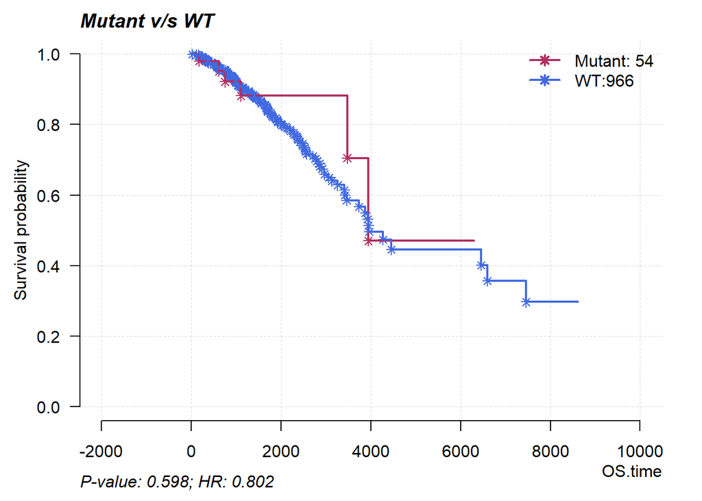

### 6.3 🧬 تحليل تأثير الطفرات على الحياة باستخدام مجموعات من الجينات

ربما لا يكون لجين واحد تأثير كبير، ولكن في بعض الحالا وجود طفرتين في جينين مختلفين في وقت واحد يسبب إما وفاة أسرع أو يساعد على العيش لفترة أطول، ولاكتشاف ذلك نقوم بإجراء هذا التحليل.

```r
# 5) تحليل البقاء لأكثر من جين

# البحث عن مجموعات جينات (مثلاً 2 جين) من بين أعلى 100 جين لتوقع البقاء

prog_geneset = survGroup(maf = maf_file, top = 100, geneSetSize = 2, time = "OS.time", Status = "vital_status", verbose = TRUE)
```

```
## ------------------
## genes: 100
## geneset size: 2
## 4950 combinations
```

```
## Looking for clinical data in annoatation slot of MAF..
```

[output not shown]

[output cut: 33 more lines]

[output not shown]

[output not shown]

[output not shown]

[output not shown]

[output not shown]

[output not shown]

[output not shown]

[output not shown]

[output not shown]

[output not shown]

[output not shown]

[output not shown]

[output not shown]

[output not shown]

[output not shown]

[output not shown]

[output not shown]

[output not shown]

[output not shown]

[output not shown]

[output not shown]

[output not shown]

[output not shown]

[output not shown]

[output not shown]

[output not shown]

[output not shown]

[output not shown]

[output not shown]

[output not shown]

[output not shown]

[output not shown]

[output not shown]

[output not shown]

[output not shown]

[output not shown]

[output not shown]

[output not shown]

[output not shown]

[output not shown]

[output not shown]

[output not shown]

[output not shown]

[output not shown]

[output not shown]

[output not shown]

[output not shown]

[output not shown]

[output not shown]

[output not shown]

[output not shown]

[output not shown]

[output not shown]

[output not shown]

[output not shown]

[output not shown]

[output not shown]

[output not shown]

[output not shown]

[output not shown]

[output not shown]

[output not shown]

[output not shown]

[output not shown]

[output not shown]

[output not shown]

[output not shown]

[output not shown]

[output not shown]

[output not shown]

[output not shown]

[output not shown]

[output not shown]

[output not shown]

[output not shown]

[output not shown]

[output not shown]

[output not shown]

[output not shown]

[output not shown]

[output not shown]

[output not shown]

[output not shown]

[output not shown]

[output not shown]

[output not shown]

[output not shown]

[output not shown]

[output not shown]

[output not shown]

[output not shown]

[output not shown]

[output not shown]

[output not shown]

[output not shown]

[output not shown]

[output not shown]

[output not shown]

[output not shown]

[output not shown]

[output not shown]

[output not shown]

[output not shown]

[output not shown]

[output not shown]

[output not shown]

[output not shown]

[output not shown]

[output not shown]

[output not shown]

[output not shown]

[output not shown]

[output not shown]

[output not shown]

[output not shown]

[output not shown]

[output not shown]

[output not shown]

[output not shown]

[output not shown]

[output not shown]

[output not shown]

[output not shown]

[output not shown]

[output not shown]

[output not shown]

[output not shown]

[output not shown]

[output not shown]

[output not shown]

[output not shown]

[output not shown]

[output not shown]

[output not shown]

[output not shown]

[output not shown]

[output not shown]

[output not shown]

[output not shown]

[output not shown]

[output not shown]

[output not shown]

[output not shown]

[output not shown]

[output not shown]

[output not shown]

[output not shown]

[output not shown]

[output not shown]

[output not shown]

[output not shown]

[output not shown]

[output not shown]

[output not shown]

[output not shown]

[output not shown]

[output not shown]

[output not shown]

[output not shown]

[output not shown]

[output not shown]

[output not shown]

[output not shown]

[output not shown]

[output not shown]

[output not shown]

[output not shown]

[output not shown]

[output not shown]

[output not shown]

[output not shown]

[output not shown]

[output not shown]

[output not shown]

[output not shown]

[output not shown]

[output not shown]

[output not shown]

[output not shown]

[output not shown]

[output not shown]

[output not shown]

[output not shown]

[output not shown]

[output not shown]

[output not shown]

[output not shown]

[output not shown]

[output not shown]

[output not shown]

[output not shown]

[output not shown]

[output not shown]

[output not shown]

[output not shown]

[output not shown]

[output not shown]

[output not shown]

[output not shown]

[output not shown]

[output not shown]

[output not shown]

[output not shown]

[output not shown]

[output not shown]

[output not shown]

[output not shown]

[output not shown]

[output not shown]

[output not shown]

[output not shown]

[output not shown]

[output not shown]

[output not shown]

[output not shown]

[output not shown]

[output not shown]

[output not shown]

[output not shown]

[output not shown]

[output not shown]

[output not shown]

[output not shown]

[output not shown]

[output not shown]

[output not shown]

[output not shown]

[output not shown]

[output not shown]

[output not shown]

[output not shown]

[output not shown]

[output not shown]

[output not shown]

[output not shown]

[output not shown]

[output not shown]

[output not shown]

[output not shown]

[output not shown]

[output not shown]

[output not shown]

[output not shown]

[output not shown]

[output not shown]

[output not shown]

[output not shown]

[output not shown]

[output not shown]

[output not shown]

[output not shown]

[output not shown]

[output not shown]

[output not shown]

[output not shown]

[output not shown]

[output not shown]

[output not shown]

[output not shown]

[output not shown]

[output not shown]

[output not shown]

[output not shown]

[output not shown]

[output not shown]

[output not shown]

[output not shown]

[output not shown]

[output not shown]

[output not shown]

[output not shown]

[output not shown]

[output not shown]

[output not shown]

[output not shown]

[output not shown]

[output not shown]

[output not shown]

[output not shown]

[output not shown]

[output not shown]

[output not shown]

[output not shown]

[output not shown]

[output not shown]

[output not shown]

[output not shown]

[output not shown]

[output not shown]

[output not shown]

[output not shown]

[output not shown]

[output not shown]

[output not shown]

[output not shown]

[output not shown]

[output not shown]

[output not shown]

[output not shown]

[output not shown]

[output not shown]

[output not shown]

[output not shown]

[output not shown]

[output not shown]

[output not shown]

[output not shown]

[output not shown]

[output not shown]

[output not shown]

[output not shown]

[output not shown]

[output not shown]

[output not shown]

[output not shown]

[output not shown]

[output not shown]

[output not shown]

[output not shown]

[output not shown]

[output not shown]

[output not shown]

[output not shown]

[output not shown]

[output not shown]

[output not shown]

[output not shown]

[output not shown]

[output not shown]

[output not shown]

[output not shown]

[output not shown]

[output not shown]

[output not shown]

[output not shown]

[output not shown]

[output not shown]

[output not shown]

[output not shown]

[output not shown]

[output not shown]

[output not shown]

[output not shown]

[output not shown]

[output not shown]

[output not shown]

[output not shown]

[output not shown]

[output not shown]

[output not shown]

[output not shown]

[output not shown]

[output not shown]

[output not shown]

[output not shown]

[output not shown]

[output not shown]

[output not shown]

[output not shown]

[output not shown]

[output not shown]

[output not shown]

[output not shown]

[output not shown]

[output not shown]

[output not shown]

[output not shown]

[output not shown]

[output not shown]

[output not shown]

[output not shown]

[output not shown]

[output not shown]

[output not shown]

[output not shown]

[output not shown]

[output not shown]

[output not shown]

[output not shown]

[output not shown]

[output not shown]

[output not shown]

[output not shown]

[output not shown]

[output not shown]

[output not shown]

[output not shown]

[output not shown]

[output not shown]

[output not shown]

[output not shown]

[output not shown]

[output not shown]

[output not shown]

[output not shown]

[output not shown]

[output not shown]

[output not shown]

[output not shown]

[output not shown]

[output not shown]

[output not shown]

[output not shown]

[output not shown]

[output not shown]

[output not shown]

[output not shown]

[output not shown]

[output not shown]

[output not shown]

[output not shown]

[output not shown]

[output not shown]

[output not shown]

[output not shown]

[output not shown]

[output not shown]

[output not shown]

[output not shown]

[output not shown]

[output not shown]

[output not shown]

[output not shown]

[output not shown]

[output not shown]

[output not shown]

[output not shown]

[output not shown]

[output not shown]

[output not shown]

[output not shown]

[output not shown]

[output not shown]

[output not shown]

[output not shown]

[output not shown]

[output not shown]

[output not shown]

[output not shown]

[output not shown]

[output not shown]

[output not shown]

[output not shown]

[output not shown]

[output not shown]

[output not shown]

[output not shown]

[output not shown]

[output not shown]

[output not shown]

[output not shown]

[output not shown]

[output not shown]

[output not shown]

[output not shown]

[output not shown]

[output not shown]

[output not shown]

[output not shown]

[output not shown]

[output not shown]

[output not shown]

[output not shown]

[output not shown]

[output not shown]

[output not shown]

[output not shown]

[output not shown]

[output not shown]

[output not shown]

[output not shown]

[output not shown]

[output not shown]

[output not shown]

[output not shown]

[output not shown]

[output not shown]

[output not shown]

[output not shown]

[output not shown]

[output not shown]

[output not shown]

[output not shown]

[output not shown]

[output not shown]

[output not shown]

[output not shown]

[output not shown]

[output not shown]

[output not shown]

[output not shown]

[output not shown]

[output not shown]

[output not shown]

[output not shown]

[output not shown]

[output not shown]

[output not shown]

[output not shown]

[output not shown]

[output not shown]

[output not shown]

[output not shown]

[output not shown]

[output not shown]

[output not shown]

[output not shown]

[output not shown]

[output not shown]

[output not shown]

[output not shown]

[output not shown]

[output not shown]

[output not shown]

[output not shown]

[output not shown]

[output not shown]

[output not shown]

[output not shown]

[output not shown]

[output not shown]

[output not shown]

[output not shown]

[output not shown]

[output not shown]

[output not shown]

[output not shown]

[output not shown]

[output not shown]

[output not shown]

[output not shown]

[output not shown]

[output not shown]

[output not shown]

[output not shown]

[output not shown]

[output not shown]

[output not shown]

[output not shown]

[output not shown]

[output not shown]

[output not shown]

```r
 #عرض أول 5 صفوف من النتيجة
head(prog_geneset, 5)
```

| Gene_combination | P_value | hr | WT | Mutant |
| --- | --- | --- | --- | --- |
| FLG_TENM1 | 0.00e+00 | 55.3 | 1015 | 5 |
| HMCN1_ASH1L | 0.00e+00 | 78.5 | 1015 | 5 |
| MUC17_BRCA2 | 0.00e+00 | 44.2 | 1015 | 5 |
| FAT3_DNAH11 | 0.00e+00 | 66.2 | 1015 | 5 |
| TENM1_ASH1L | 9.59e-14 | 21.7 | 1015 | 5 |

### 6.4 🪢 رسم نتائج التحليل لمجموعة من الجينات

```r
# مثال: تحليل البقاء لجيني MUC17 و BRCA2

mafSurvGroup(maf = maf_file, geneSet = c("MUC17", "BRCA2"), time = "OS.time", Status = "vital_status")
```

```
## Looking for clinical data in annoatation slot of MAF..
```

```
## Median survival..
```

[output not shown]

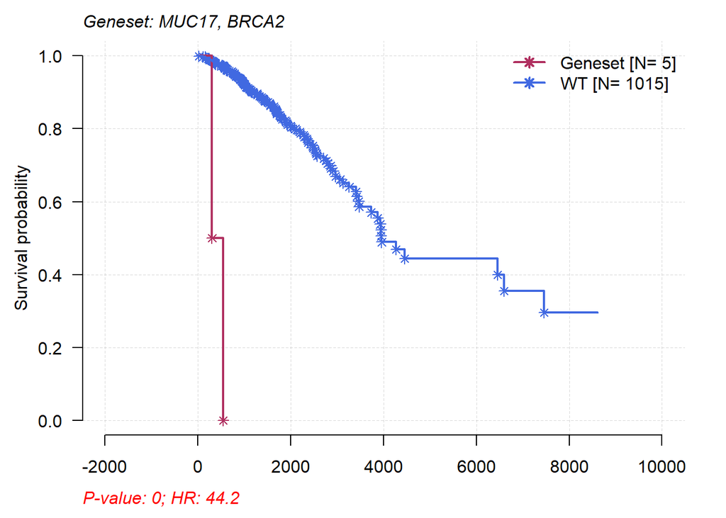

## 7. ربط الطفرات الجينية بالبيانات السريرية

### 7.1 👩‍⚕️ هل توجد جينات تترافق طفراتها مع جنس المريض؟

#### 7.1.1 📈 نتأكد من أن البيانات مناسبة لإجراء التحليل الإحصائي.

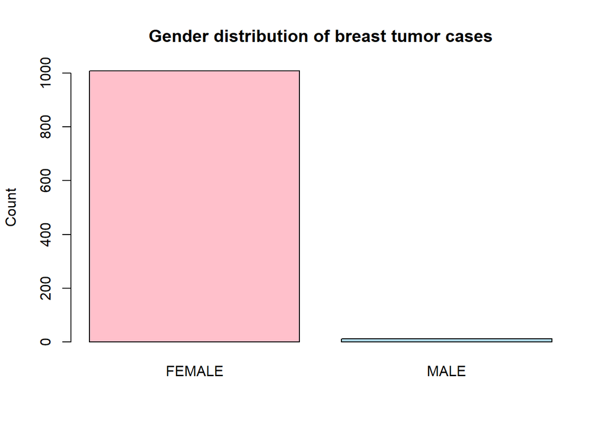

```r
# توزيع العينات حسب الجنس

table_gender <- table(maf_file@clinical.data$gender)

barplot(table_gender,
        main = "Gender distribution of breast tumor cases",
        ylab = "Count",
        col = c("pink", "lightblue"))
```

نستنتج أن المقارنة هنا لن تنجح إحصائيا بسبب الاختلاف الكبير بعدد العينات بين الذكور والإناث.

### 7.2 ☢️ هل توجد جينات تترافق طفراتها مع حالة العلاج الإشعاعي للمريض؟

#### 7.2.1 نتأكد من أن البيانات مناسبة لإجراء التحليل الإحصائي.

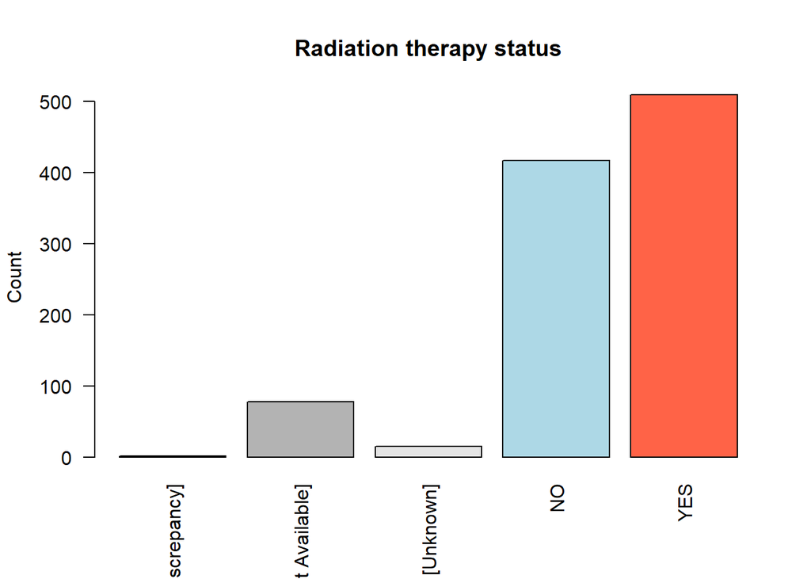

```r
# ملخص حالة العلاج الإشعاعي من البيانات السريرية

table_radiation <- table(maf_file@clinical.data$radiation_therapy)

#رسم توزيع الحالات

barplot(table_radiation,
        main = "Radiation therapy status",
        ylab = "Count",
        col = c("orange", "gray70", "gray90", "lightblue", "tomato"),
        las = 2)  # rotate labels for readability
```

#### 7.2.2 نحتاج لإزالة البيانات الغير مُسجلة أو المفقودة.

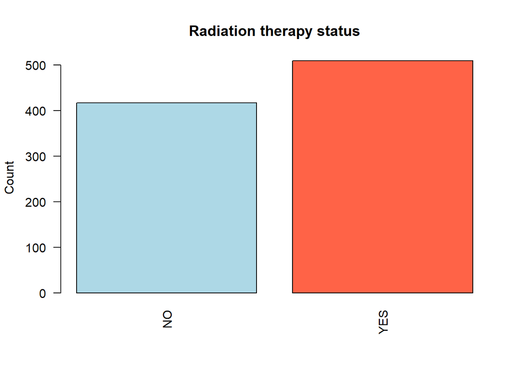

```r
# توحيد القيم إلى YES/NO فقط، وما عدا ذلك يحوّل إلى NA
maf_file@clinical.data$radiation_therapy <- ifelse(
  maf_file@clinical.data$radiation_therapy %in% c("NO", "YES"),
  maf_file@clinical.data$radiation_therapy,
  NA
)

# إعادة حساب الجدول بعد التنظيف
table_radiation <- table(maf_file@clinical.data$radiation_therapy)

# رسم التوزيع بعد التنظيف (YES/NO فقط)
barplot(table_radiation,
        main = "Radiation therapy status",
        ylab = "Count",
        col = c( "lightblue", "tomato"),
        las = 2)  # rotate labels for readability
```

#### 7.2.3 📈 نقوم الآن بإجراء الاختبار الإحصائي.

```r
#Clinical feature enrichment using maftools

radiation_therapy.ce = clinicalEnrichment(maf = maf_file, clinicalFeature = 'radiation_therapy')
```

```
## Sample size per factor in radiation_therapy:
```

```
##
##  NO YES
## 417 509
```

```r
head(radiation_therapy.ce)
```

```
## $pairwise_comparision
##       Hugo_Symbol Feature_1 Feature_2 n_mutated_Feature1 n_mutated_Feature2
##            <char>    <char>    <char>             <char>             <char>
##    1:       GATA3       YES        NO          43 of 509          74 of 417
##    2:       CECR2       YES        NO           0 of 509          10 of 417
##    3:     LEPREL1       YES        NO           0 of 509          10 of 417
##    4:        TAF1       YES        NO           5 of 509          19 of 417
##    5:      SLC9C2       YES        NO           0 of 509           9 of 417
##   ---
## 4707:      ZNF681       YES        NO           3 of 509           3 of 417
## 4708:        ZNF7       YES        NO           3 of 509           3 of 417
## 4709:      ZNF727       YES        NO           3 of 509           3 of 417
## 4710:      ZNF808       YES        NO           3 of 509           2 of 417
## 4711:      ZNF835       YES        NO           3 of 509           2 of 417
##                fdr
##              <num>
##    1: 2.638048e-05
##    2: 3.229996e-04
##    3: 3.229996e-04
##    4: 6.993148e-04
##    5: 7.259574e-04
##   ---
## 4707: 1.000000e+00
## 4708: 1.000000e+00
## 4709: 1.000000e+00
## 4710: 1.000000e+00
## 4711: 1.000000e+00
##
## $groupwise_comparision
##       Hugo_Symbol Group1 Group2 n_mutated_group1 n_mutated_group2      p_value
##            <char> <char> <char>           <char>           <char>        <num>
##    1:       GATA3     NO   Rest        74 of 417        54 of 603 4.707496e-05
##    2:       GATA3    YES   Rest        43 of 509        85 of 511 9.527331e-05
##    3:       CECR2    YES   Rest         0 of 509        14 of 511 1.115576e-04
##    4:        HEPH     NO   Rest        11 of 417         1 of 603 3.731997e-04
##    5:        TAF1     NO   Rest        19 of 417         6 of 603 6.136316e-04
##   ---
## 9418:      ZNF808     NO   Rest         2 of 417         4 of 603 1.000000e+00
## 9419:      ZNF808    YES   Rest         3 of 509         3 of 511 1.000000e+00
## 9420:      ZNF835     NO   Rest         2 of 417         4 of 603 1.000000e+00
```

[output cut: 10 more lines]

```
## 9418:  0.7219096 0.06499789   5.0635451 1.0000000
## 9419:  1.0039488 0.13381620   7.5321046 1.0000000
## 9420:  0.7219096 0.06499789   5.0635451 1.0000000
## 9421:  1.0039488 0.13381620   7.5321046 1.0000000
## 9422:  0.7219096 0.06499789   5.0635451 1.0000000
##
## $cf_sizes
##        cf     N
##    <char> <int>
## 1:     NO   417
## 2:    YES   509
## 3:   <NA>    94
##
## $clinicalFeature
## [1] "radiation_therapy"
```

```r
# إبراز المقارنات ذات الدلالة الإحصائية (p < 0.05)
radiation_therapy.ce$pairwise_comparision[fdr < 0.05]
```

| Hugo_Symbol | Feature_1 | Feature_2 | n_mutated_Feature1 | n_mutated_Feature2 | fdr |
| --- | --- | --- | --- | --- | --- |
| GATA3 | YES | NO | 43 of 509 | 74 of 417 | 2.638048e-05 |
| CECR2 | YES | NO | 0 of 509 | 10 of 417 | 3.229996e-04 |
| LEPREL1 | YES | NO | 0 of 509 | 10 of 417 | 3.229996e-04 |
| TAF1 | YES | NO | 5 of 509 | 19 of 417 | 6.993148e-04 |
| SLC9C2 | YES | NO | 0 of 509 | 9 of 417 | 7.259574e-04 |
| PCDH18 | YES | NO | 0 of 509 | 8 of 417 | 1.629410e-03 |
| USP7 | YES | NO | 0 of 509 | 8 of 417 | 1.629410e-03 |
| HEPH | YES | NO | 1 of 509 | 11 of 417 | 1.738880e-03 |
| CDK12 | YES | NO | 1 of 509 | 10 of 417 | 3.435526e-03 |
| ECE1 | YES | NO | 1 of 509 | 10 of 417 | 3.435526e-03 |

[output cut: 153 more lines]

#### 7.2.4 📈 استخراج الجينات المرتبط بالعلاج الاشعاعي بطريقة أكثر صحة إحصائيا

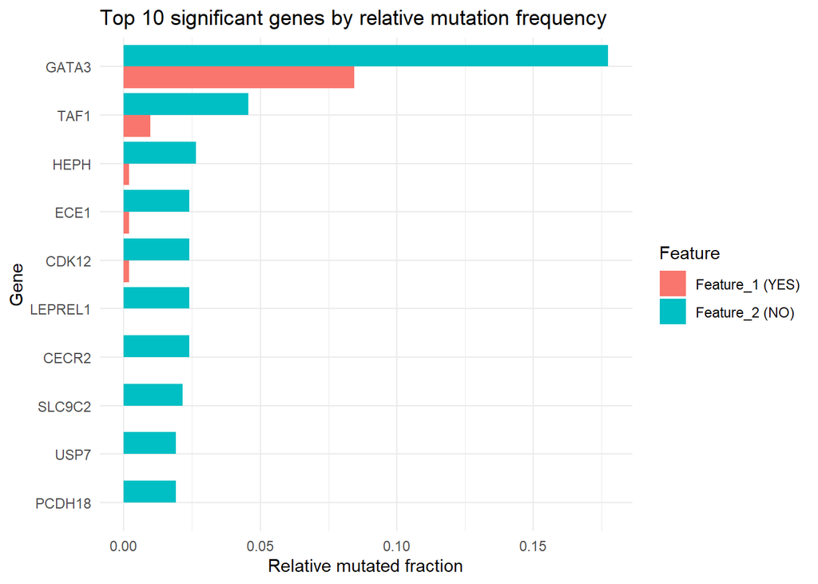

```r
#Extract pairwise comparisons table
df <- radiation_therapy.ce$pairwise_comparision

# extract numerator/denominator and compute relative frequencies

df[, c("mut1", "total1") := tstrsplit(n_mutated_Feature1, " of ", fixed=TRUE)]
df[, c("mut2", "total2") := tstrsplit(n_mutated_Feature2, " of ", fixed=TRUE)]

# Convert to numeric
df[, `:=`(mut1 = as.numeric(mut1),
          total1 = as.numeric(total1),
          mut2 = as.numeric(mut2),
          total2 = as.numeric(total2))]

# Compute relative values
df[, rel1 := mut1 / total1]
df[, rel2 := mut2 / total2]

df <- df[order(-rel1, -rel2)]
df <- df[fdr < 0.01]

# Take top 10 significant genes
top10 <- df[order(fdr)][1:10]


# Reshape to long format for ggplot
plotdf <- melt(top10,
               id.vars = "Hugo_Symbol",
               measure.vars = c("rel1", "rel2"),
               variable.name = "Feature",
               value.name = "Relative")

# Make Feature labels clearer
plotdf[, Feature := fifelse(Feature == "rel1", "Feature_1 (YES)", "Feature_2 (NO)")]

# Plot
ggplot(plotdf, aes(x = reorder(Hugo_Symbol, Relative), y = Relative, fill = Feature)) +
  geom_bar(stat = "identity", position = position_dodge()) +
  coord_flip() +
  labs(x = "Gene", y = "Relative mutated fraction",
       title = "Top 10 significant genes by relative mutation frequency") +
  theme_minimal()
```

#### 7.2.5 🎯 Effect Size vs Significance

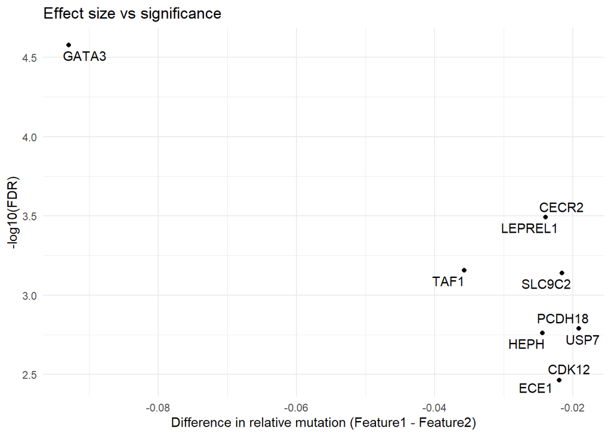

```r
# فرق النسبة بين المجموعتين كحجم تأثير مبسّط


top10[, diff_rel := rel1 - rel2]

ggplot(top10, aes(x = diff_rel, y = -log10(fdr), label = Hugo_Symbol)) +
  geom_point() +
  geom_text_repel() +
  theme_minimal() +
  labs(x = "Difference in relative mutation (Feature1 - Feature2)",
       y = "-log10(FDR)",
       title = "Effect size vs significance")
```

## 8. استخراج البيانات الجينية والدوائية

### 8.1 💊 البحث عن الأدوية المناسبة لكل جين في ملف MAF

```r
# البحث عن تفاعلات دواء-جين للوحة الجينات المستخلصة من الـ MAF
dgi = drugInteractions(maf = maf_file, fontSize = 0.75)
```

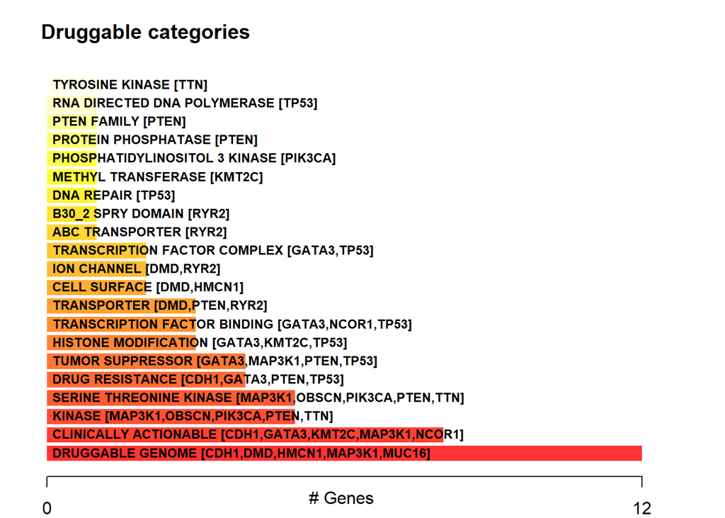

### 8.2 ماذا عن الأدوية المُسجلة لجين واحد فقط؟

```r
# استرجاع التفاعلات الدوائية لجين محدد
dnmt3a.dgi = drugInteractions(genes = "TP53", drugs = TRUE)
```

```
## Number of claimed drugs for given genes:
##      Gene     N
##    <char> <int>
## 1:   TP53   193
```

```r
# عرض أعمدة مختارة مفيدة للتقارير
dnmt3a.dgi[,.(Gene, interaction_types, drug_name, drug_claim_name)]
```

| Gene | interaction_types | drug_name | drug_claim_name |
| --- | --- | --- | --- |
| TP53 |  |  | CTX-1 |
| TP53 |  | GEMCITABINE | Gemcitabine |
| TP53 |  | GRANISETRON | GRANISETRON |
| TP53 |  | EPIRUBICIN | epirubicin |
| TP53 |  |  | TOPICAL CORTICOSTEROIDS |
| TP53 |  | TRAMETINIB | Trametinib |
| TP53 | vaccine |  | AD.P53-DC |
| TP53 |  |  | Cisplatin |
| TP53 |  | YONDELIS | YONDELIS |
| TP53 |  | DOXORUBICIN | Doxorubicin |

[output cut: 183 more lines]

```
## Summarizing signalling pathways [Sanchez-Vega et al., https://doi.org/10.1016/j.cell.2018.03.035]
```

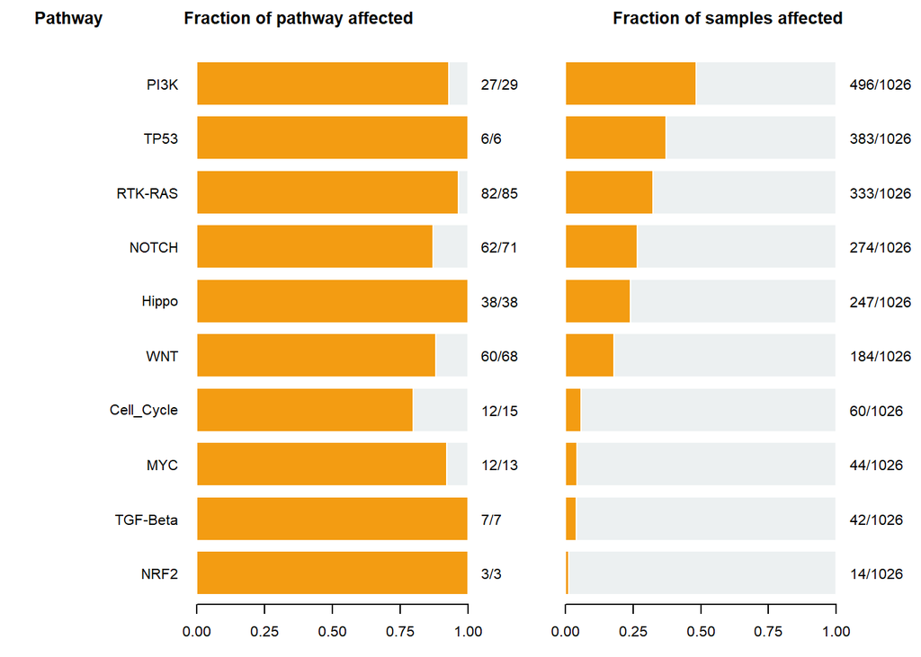

```r
pws = pathways(maf = maf_file, plotType = 'bar')
```

```r
pws
```

| Pathway | N | n_affected_genes | fraction_affected | Mutated_samples | Fraction_mutated_samples |
| --- | --- | --- | --- | --- | --- |
| PI3K | 29 | 27 | 0.9310345 | 496 | 0.48343080 |
| TP53 | 6 | 6 | 1.0000000 | 383 | 0.37329435 |
| RTK-RAS | 85 | 82 | 0.9647059 | 333 | 0.32456140 |
| NOTCH | 71 | 62 | 0.8732394 | 274 | 0.26705653 |
| Hippo | 38 | 38 | 1.0000000 | 247 | 0.24074074 |
| WNT | 68 | 60 | 0.8823529 | 184 | 0.17933723 |
| Cell_Cycle | 15 | 12 | 0.8000000 | 60 | 0.05847953 |
| MYC | 13 | 12 | 0.9230769 | 44 | 0.04288499 |
| TGF-Beta | 7 | 7 | 1.0000000 | 42 | 0.04093567 |
| NRF2 | 3 | 3 | 1.0000000 | 14 | 0.01364522 |

## 10. 🧩 دراسة تنوع الطفرات داخل الأورام

**🔹 ما الفكرة؟**

الأورام ليست كتلة خلوية متجانسة، بل غالبًا تتكون من عدة مستعمرات (clones) من الخلايا، كل مستعمرة تحمل مجموعة من الطفرات المميزة.

الطفرات التي تحدث في بداية نشأة الورم (founder mutations) تظهر بنسبة عالية (VAF مرتفع).

الطفرات التي تحدث لاحقًا أثناء تطور الورم تظهر في subclones (VAF أقل).

📊 لذلك، توزيع VAF يمكن تقسيمه إلى clusters → كل cluster يمثل مجموعة من الطفرات المرتبطة بمستعمرة معينة.

```r
# mclust مطلوبة لتجميع التوزيعات (Gaussian mixture models)
library("mclust")
```

نخار عينة واحدة فقط لندرس كيف تتنوع الطفرات في هذه العينة

```r
hetero_breast_tumor = inferHeterogeneity(maf = maf_file, tsb = 'TCGA-3C-AAAU-01A-11D-A41F-09')
```

```
## t_vaf field is missing, but found t_ref_count & t_alt_count columns. Estimating vaf..
```

```
## Processing TCGA-3C-AAAU-01A-11D-A41F-09..
```

```r
print(hetero_breast_tumor$clusterMeans)
```

```
##            Tumor_Sample_Barcode cluster    meanVaf
##                          <fctr>  <char>      <num>
## 1: TCGA-3C-AAAU-01A-11D-A41F-09       1 0.07596995
## 2: TCGA-3C-AAAU-01A-11D-A41F-09       2 0.31535435
## 3: TCGA-3C-AAAU-01A-11D-A41F-09       3 0.76904571
## 4: TCGA-3C-AAAU-01A-11D-A41F-09 outlier 0.17777778
```

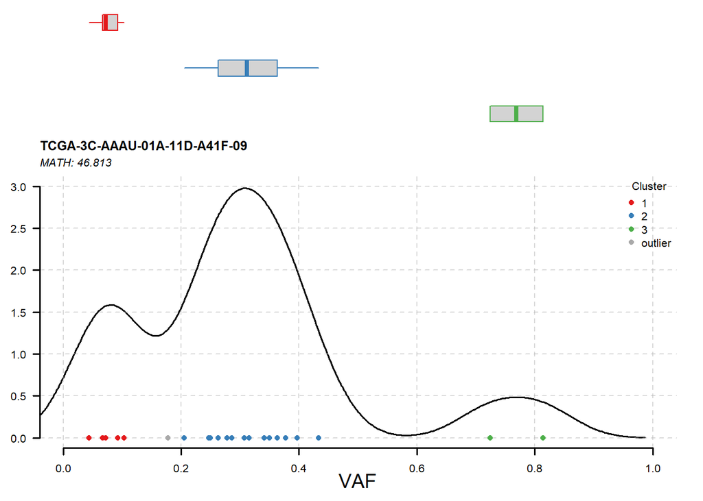

```r
#Visualizing results
plotClusters(clusters = hetero_breast_tumor)
```

**🔹 الاستنتاج:**

الورم في هذه العينة متغاير بشدة (MATH ~47).

هناك على الأقل 3 مجموعات/مستعمرات مختلفة من الخلايا:

طفرات subclonal (VAF منخفض).

طفرات clonal ثانوية (VAF متوسط).

طفرات مؤسِّسة أو جيرملين (VAF عالي).

**🔬 هذا مهم لأنه:**

يعكس تطور الورم (tumor evolution).

يفسر لماذا بعض الأورام مقاومة للعلاج (لأن مستعمرات فرعية قد تنجو).

يساعد في تحديد العلاجات المستهدفة بناءً على الطفرات المشتركة بين جميع الخلايا الورمية (clonal mutations).

## 11. Mutation Signature

كل ورم يترك خلفه بصمة (Signature) خاصة به، عبارة عن نمط مميز من الطفرات (substitution types). هذه البصمات مرتبطة غالبًا بآليات بيولوجية محددة (مثل: APOBEC, UV, التدخين, MMR deficiency … إلخ). 📊 التحليل يتم عبر:

بناء مصفوفة الطفرات (trinucleotide mutation matrix).

استخدام NMF (non-negative matrix factorization) لاستخراج عدد n من البصمات.

مقارنة البصمات المستخرجة مع قاعدة بيانات COSMIC Signatures لمعرفة السبب المحتمل للطفرات.

يساعدنا في عمل ذلك حزمة NMF والتي ستقوم بحساب عدد البصمات المتوقعة.

```r
library('NMF')
library("BSgenome.Hsapiens.UCSC.hg19", quietly = TRUE)
```

### 11.1 Trinucleotides

**🔹ما معنى Trinucleotides analysis؟**

عندما نحلل الطفرات، لا يكفي فقط أن نعرف أن الطفرة مثلًا C>T، لأن سياق القاعدة قبلها وبعدها (±1 base) مهم جدًا.

مثال: الطفرة C>T قد تحدث في تسلسل TCA → TTA أو في GCG → GTG.

هذه السياقات الثلاثية (trinucleotides) تساعدنا على تحديد بصمة الطفرة (Mutational signature).

دالة trinucleotideMatrix() في maftools:

تنشئ مصفوفة تصنيف الطفرات إلى 96 نوعًا مختلفًا (6 أنواع بدائل أساسية × 16 سياق ثلاثي).

```r
laml.tnm = trinucleotideMatrix(maf = maf_file, prefix = 'chr', add = TRUE, ref_genome = "BSgenome.Hsapiens.UCSC.hg19")
```

```
## -Extracting 5' and 3' adjacent bases
## -Extracting +/- 20bp around mutated bases for background C>T estimation
## -Estimating APOBEC enrichment scores
## --Performing one-way Fisher's test for APOBEC enrichment
## ---APOBEC related mutations are enriched in  28.947 % of samples (APOBEC enrichment score > 2 ;  297  of  1026  samples)
## -Creating mutation matrix
## --matrix of dimension 1026x96
```

[output not shown]

```
## Showing top 10 of 1145 differentially mutated genes
```

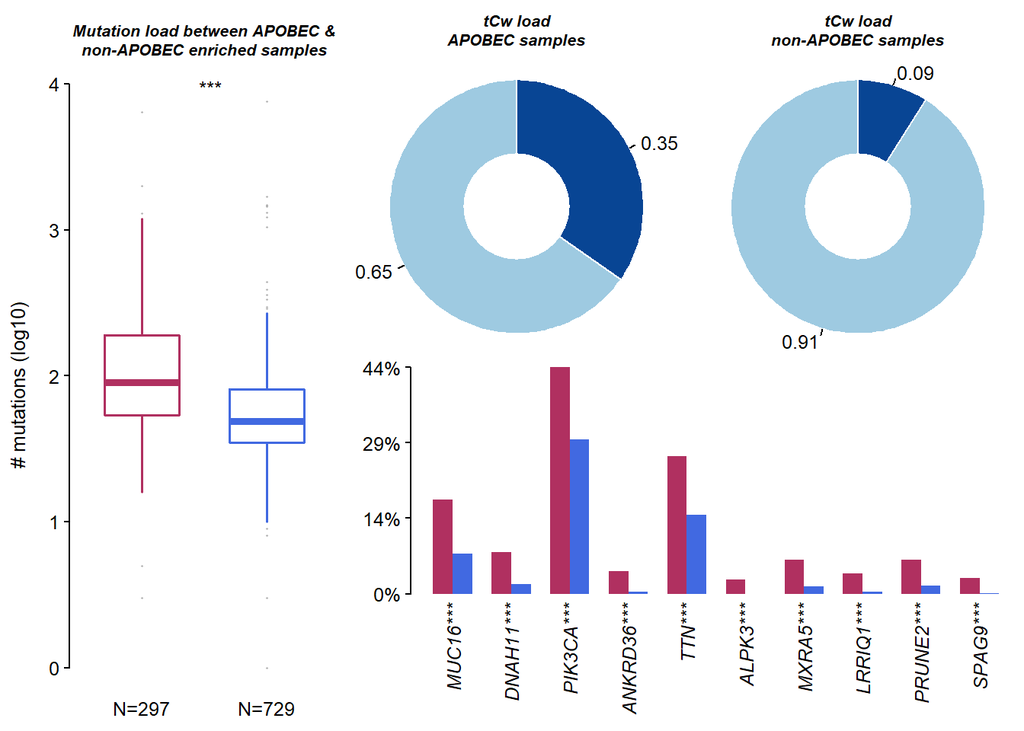

```
## $results
## Index: <Hugo_Symbol>
##        Hugo_Symbol Enriched nonEnriched         pval         or     ci.up
##             <char>    <num>       <num>        <num>      <num>     <num>
##     1:       MUC16       55          57 2.413658e-06  2.6764829  4.069095
##     2:      DNAH11       24          14 1.002143e-05  4.4819876  9.517889
##     3:      PIK3CA      132         220 1.789742e-05  1.8497805  2.466852
##     4:     ANKRD36       13           3 1.879786e-05 11.0488789 60.920774
##     5:         TTN       80         113 4.553626e-05  2.0082427  2.815333
##    ---
## 12042:     ZSCAN5B        1           2 1.000000e+00  1.2277415 23.669519
## 12043:      ZSCAN9        1           2 1.000000e+00  1.2277415 23.669519
## 12044:      ZSWIM5        1           3 1.000000e+00  0.8177302 10.231284
## 12045:      ZYG11B        0           2 1.000000e+00  0.0000000 13.080351
## 12046:         ZYX        1           2 1.000000e+00  1.2277415 23.669519
##            ci.low    adjPval
##             <num>      <num>
##     1: 1.76007865 0.02907493
##     2: 2.18965521 0.05660974
##     3: 1.38669863 0.05660974
##     4: 3.00522928 0.05660974
##     5: 1.42906045 0.08214252
##    ---
## 12042: 0.02074589 1.00000000
## 12043: 0.02074589 1.00000000
## 12044: 0.01552625 1.00000000
## 12045: 0.00000000 1.00000000
## 12046: 0.02074589 1.00000000
##
## $SampleSummary
## Key: <Cohort>
##         Cohort SampleSize    Mean Median
##         <char>      <num>   <num>  <num>
## 1:    Enriched        297 124.724     59
## 2: nonEnriched        729  66.970     34
```

```r
plotApobecDiff(tnm = laml.tnm, maf = maf_file, pVal = 0.2)
```

**🔹ما هو APOBEC؟**

APOBEC = اختصار لـ Apolipoprotein B mRNA Editing Catalytic Polypeptide-like.

هي عائلة من الإنزيمات في الجسم وظيفتها الطبيعية: مكافحة الفيروسات عبر إدخال طفرات في DNA الفيروس.

لكن أحيانًا، هذه الإنزيمات تخطئ وتبدأ بإحداث طفرات في DNA الخلايا البشرية نفسها.

✴️ النمط المميز لطفرات APOBEC:

غالبًا تكون C>T أو C>G.

وتحدث في سياق tCw (أي C في وسط ثلاثية TCA أو TCT).

**🔹ما الهدف من تحليل APOBEC في السرطان؟**

تحديد إذا كان الورم غني بـ APOBEC activity (APOBEC-enriched):

يعني أن جزءًا كبيرًا من طفراته ناتج عن نشاط هذه الإنزيمات.

مقارنة APOBEC vs non-APOBEC samples (plotApobecDiff):

نعرف هل هناك فرق في عبء الطفرات (mutation load).

نعرف أي جينات تتأثر أكثر في العينات الغنية بـ APOBEC (مثل PIK3CA).

تفسير البصمة الجينية:

إذا وجدنا أن معظم الطفرات من نوع APOBEC → نستنتج أن هذا الإنزيم ساهم في تطور الورم.

أهمية سريرية:

الأورام ذات الطفرات الناتجة عن APOBEC أحيانًا تكون أكثر متحولة (hypermutated).

هذا قد يجعلها أكثر استجابة لعلاجات مناعية مثل Immune checkpoint inhibitors.

### 11.2 🔢 Estimate Optimal Number of Signatures

نستخدم NMF لتوقع العدد المناسب من البصمات.

```r
laml.sign = estimateSignatures(mat = laml.tnm, nTry = 6)
```

```
## -Running NMF for 6 ranks
## Compute NMF rank= 2  ... + measures ... OK
## Compute NMF rank= 3  ... + measures ... OK
## Compute NMF rank= 4  ... + measures ... OK
## Compute NMF rank= 5  ... + measures ... OK
## Compute NMF rank= 6  ... + measures ... OK
```

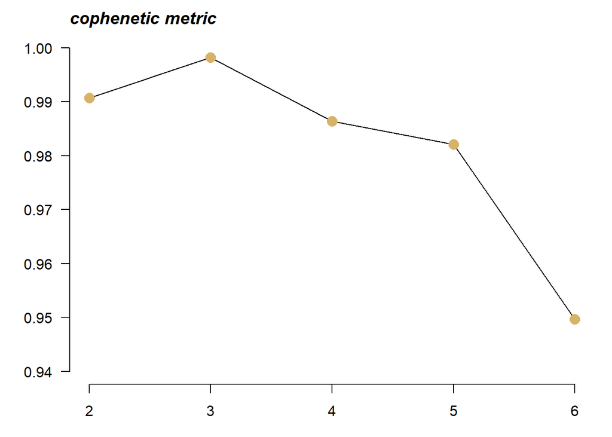

```
## -Finished in 00:12:07 elapsed (55.0s cpu)
```

```r
plotCophenetic(res = laml.sign)
```

### 11.3 ✂️ Extract NMF signatures for chosen K

نقوم الآن باستخراج البصمات.

```r
NMF::nmf.options("verbose" = 0)
laml.sig = maftools::extractSignatures(mat = laml.tnm, n = 3,  parallel = 1)
```

```
## -Running NMF for factorization rank: 3
```

```
## -Finished in11.2s elapsed (9.490s cpu)
```

### 11.4 🔍 Compare against COSMIC reference signatures

**🔹 ما هي COSMIC؟**

COSMIC هو اختصار لـ: Catalogue Of Somatic Mutations In Cancer

📌 وهو أكبر قاعدة بيانات عالمية متخصصة في:

الطفرات الجسدية (Somatic mutations) المكتشفة في السرطان.

أنشئ في معهد سانغر (Sanger Institute – UK).

**🔹 محتوى COSMIC**

بيانات من آلاف الأورام البشرية.

يشمل أنواع مختلفة من الطفرات:

Single Nucleotide Variants (SNVs) (مثل C>T).

Insertions & Deletions (InDels).

Copy Number Variations (CNVs).

Fusions/Translocations.

أيضًا يحتوي على Mutational Signatures (بصمات الطفرات) التي طورها Alexandrov وآخرون.

**🔹 أهمية COSMIC**

مرجع عالمي: أي طفرة تُكتشف في السرطان يمكن مقارنتها ببيانات COSMIC لمعرفة:

هل هي معروفة مسبقًا؟

هل تعتبر طفرة “driver” (مسببة للسرطان) أم “passenger” (طفرة عشوائية)؟

تحليل البصمات الطفرية:

COSMIC صنف عشرات البصمات الطفرية (Mutational Signatures, SBS, DBS, ID signatures).

كل بصمة مرتبطة بآلية معينة (مثل التدخين، الأشعة فوق البنفسجية، APOBEC، خلل إصلاح DNA … إلخ).

أداة للبحث العلمي والسريري:

يستخدمها الباحثون لتفسير بيانات NGS.

الأطباء يمكن أن يستفيدوا منها لتحديد الأهداف العلاجية (Therapeutic targets).

```r
laml.v3.cosm = compareSignatures(nmfRes = laml.sig, sig_db = "SBS")
```

```
## -Comparing against COSMIC signatures
```

```
## --Found Signature_1 most similar to SBS2
```

```
##    Aetiology: APOBEC Cytidine Deaminase (C>T) [cosine-similarity: 0.767]
```

```
## --Found Signature_2 most similar to SBS6
```

```
##    Aetiology: defective DNA mismatch repair [cosine-similarity: 0.834]
```

```
## --Found Signature_3 most similar to SBS10b
```

```
##    Aetiology: Polymerase epsilon exonuclease domain mutations [cosine-similarity: 0.883]
```

### 11.5 ♨️ Heatmap: cosine similarity to validated signatures

نُقارن بالبصمات الوراثية التي لدينا بالبصمات المسجلة في قاعدة بيانات COSMIC باستخدام طريقة احصائية تسمى: cosine similarity.

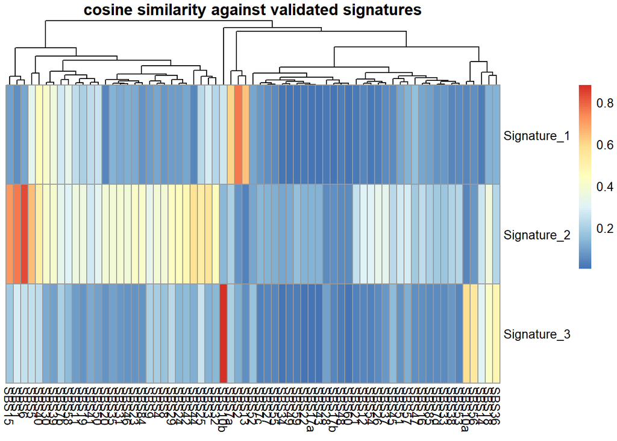

```r
library('pheatmap')
pheatmap::pheatmap(mat = laml.v3.cosm$cosine_similarities, cluster_rows = FALSE, main = "cosine similarity against validated signatures")
```

### 11.6 Plot extracted signatures (SBS labels)

هذا الرسم هو الخطوة النهائية في تحليل الـ mutational signatures:

يوضح أنماط الطفرات (96-contexts).

يربطها بأشهر البصمات العالمية (SBS signatures).

يساعد في تفسير الطفرات من منظور بيولوجي وسريري.

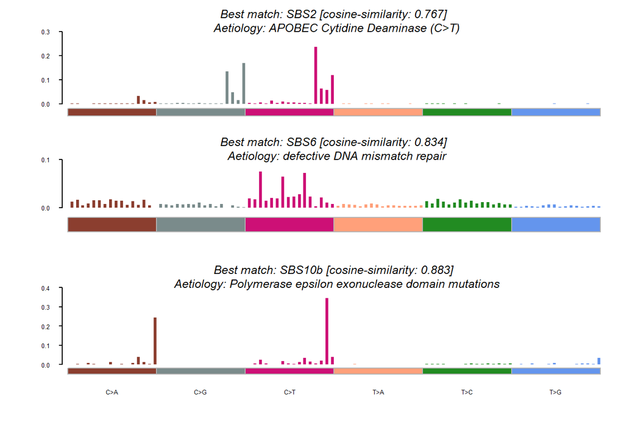

```r
maftools::plotSignatures(nmfRes = laml.sig, title_size = 1.2, sig_db = "SBS")
```

**🔹 شرح النتائج المعروضة:**

**📌 Signature 1 → SBS2** Cosine similarity: 0.767

Aetiology: نشاط إنزيم APOBEC (Cytidine Deaminase) الذي يحول C إلى T (وأحيانًا C إلى G).

النمط المميز: ارتفاع في طفرات C>T في سياق TCN (tCw).

الأهمية:

شائع في سرطانات الثدي والرئة وعنق الرحم.

مرتبط بزيادة الحمل الطفري (hypermutation).

**📌 Signature 2 → SBS6** Cosine similarity: 0.834

Aetiology: خلل في DNA mismatch repair (MMR defect).

النمط المميز: انتشار طفرات متنوعة خاصة في C>T و C>A.

الأهمية:

موجود في سرطانات القولون والمستقيم (microsatellite instability – MSI).

سريريًا: الأورام ذات MMR-deficiency غالبًا تستجيب بشكل جيد للعلاج المناعي (immune checkpoint inhibitors).

**📌 Signature 3 → SBS10b** Cosine similarity: 0.883

Aetiology: طفرات في Polymerase epsilon (POLE) exonuclease domain.

النمط المميز: نسبة عالية جدًا من C>T (وخاصة في سياقات معينة).

الأهمية:

الأورام ذات طفرات POLE عادة تكون hypermutated.

يمكن أن تكون أكثر مناعة (high neoantigen load) وبالتالي مرشحة للعلاج المناعي.

🔹 الاستنتاج:

في هذه البيانات، تم تحديد 3 بصمات رئيسية للطفرات:

APOBEC (SBS2) → إنزيم يسبب C>T.

MMR defect (SBS6) → خلل إصلاح DNA.

POLE mutations (SBS10b) → عطب في إنزيم البوليميراز.

➡️ هذه النتائج تعكس أن الورم المدروس نشأ من تعدد آليات طفرية مختلفة (enzyme-induced, repair-defect, polymerase-defect).

#ختاما

## 🔬 في هذا التحليل باستخدام maftools:

1. بدأنا بـ قراءة بيانات الطفرات (MAF file) واستكشاف أهم الجينات المتأثرة (oncoplot).
2. حللنا أنماط الطفرات الأساسية (Transition/Transversion, VAF distribution).
3. درسنا العلاقات بين الجينات المتحورة (co-occurrence vs mutual exclusivity).
4. قيّمنا تغايرية الورم (Tumor heterogeneity) باستخدام VAF clustering و MATH score.
5. أجرينا تحليل Mutational Signatures:

5.1 استخراج البصمات الطفرية بالـ NMF.

5.2 تحديد العدد الأمثل للبصمات (cophenetic metric).

5.4 تفسير أهم البصمات (APOBEC, MMR defect, POLE mutations).

## **📌 الخلاصة:**

هذا التحليل مكّنّا من رسم صورة شاملة عن المشهد الجينومي للورم، بدءًا من الطفرات الفردية إلى البصمات الطفرية الكاملة، مع تفسير بيولوجي وسريري محتمل. هذه المعلومات أساسية لفهم آليات نشوء الورم (tumorigenesis) وتحديد أهداف علاجية محتملة (مثل الأورام ذات MMR-deficiency أو POLE mutations التي تستجيب للعلاج المناعي).

✨ بهذا نكون قد أنهينا الـ workflow التحليلي باستخدام maftools.